# STA 141B HW 4

Noam Gafni

2025-05-25

```r
source("STA141BHW4.R")
```

## Task 1

### Exploration

- I searched the files in the network tab of the developer tools until I found a json file named “search” that contained the information that I wanted to extract.
- I kept adding random headers to try to bypass the verification system until it worked. Luckily I didn’t have to use the cookie, which expires, so I don’t have to update my header periodically.
- Once I got access to JSON file I looked at the nested list (llist) in R, and dug around until I found the df that I wanted to extract (hits).
- I then added another column in the df and set it to the search query so that I could do some verification with the resulting dataframes (making my salary box plot).

```r
ds  <- jobscrape("Data Scientist")
st  <- jobscrape("Statistician")
da  <- jobscrape("Data Analyst")
pr  <- jobscrape("Programmer")
ml  <- jobscrape("Machine Learning")
ai  <- jobscrape("Artificial Intelligence")
```

```r
head(ds)
```

```
##                 job_title        company_name       id
## 1 Senior Data Scientist I fa-ewgu-saasfaprod1 96585878
## 2       Data Engineer III fa-exki-saasfaprod1 96585879
## 3          Data Scientist         sensortower 96583041
## 4          Data Scientist                 cat 96583557
## 5          Data Scientist             circlek 96583565
## 6          Data Scientist         sensortower 96583941
##                                                                                                job_posting_link
## 1       https://fa-ewgu-saasfaprod1.fa.ocs.oraclecloud.com/hcmUI/CandidateExperience/en/sites/CX_2001/job/20227
## 2          https://fa-exki-saasfaprod1.fa.ocs.oraclecloud.com/hcmUI/CandidateExperience/en/sites/CX_1/job/23168
## 3                                        https://jobs.lever.co/sensortower/f1c0ab0e-4233-4302-b799-5c4d010942e2
## 4 https://cat.wd5.myworkdayjobs.com/en-US/caterpillarcareers/job/Bangalore-Karnataka/Data-Scientist_R0000306741
## 5  https://circlek.wd3.myworkdayjobs.com/en-US/circlekstorejobs/job/Support-Office-India/Data-Scientist_R507257
## 6                                        https://jobs.lever.co/sensortower/9498b05f-e775-43b3-a0a4-333ccffaf8e9
##            city       country is_remote       date                createdAt
```

[output cut: 20 more lines]

```r
head(st)
```

```
##                                             job_title company_name       id
## 1 Principal Statistician - Peripheral Vascular Health    medtronic 96585403
## 2 Principal Statistician - Peripheral Vascular Health    medtronic 96585414
## 3                   Senior Statistical Programmer FSP       iblyjb 96585832
## 4      Principal Programmer - Statistical Programming  astrazeneca 96583527
## 5                      R&D - EGDS - Statistician - CD       sanofi 96463588
## 6                Principal Statistical Programmer FSP       iblyjb 96461753
##                                                                                                                                                                           job_posting_link
## 1           https://medtronic.wd1.myworkdayjobs.com/en-US/medtroniccareers/job/Mounds-View-Minnesota-United-States-of-America/Principal-Statistician---Peripheral-Vascular-Health_R29743-1
## 2 https://medtronic.wd1.myworkdayjobs.com/en-US/redeploymentmedtroniccareers/job/Mounds-View-Minnesota-United-States-of-America/Principal-Statistician---Peripheral-Vascular-Health_R29743
## 3                                                                                                   https://iblyjb.fa.ocs.oraclecloud.com/hcmUI/CandidateExperience/en/sites/cytel/job/687
## 4                                                    https://astrazeneca.wd3.myworkdayjobs.com/en-US/careers/job/India---Bangalore/Principal-Programmer---Statistical-Programming_R-227889
## 5                                                                             https://sanofi.wd3.myworkdayjobs.com/en-US/sanoficareers/job/Chengdu/R-D---EGDS---Statistician---CD_R2805802
## 6                                                                                                   https://iblyjb.fa.ocs.oraclecloud.com/hcmUI/CandidateExperience/en/sites/cytel/job/557
##            city       country is_remote       date                createdAt
```

[output cut: 20 more lines]

```r
head(da)
```

```
##                 job_title        company_name       id
## 1       Data Engineer III fa-exki-saasfaprod1 96585879
## 2 Senior Data Scientist I fa-ewgu-saasfaprod1 96585878
## 3            Data Analyst              Fiserv 96583476
## 4            Data Analyst             equifax 96583579
## 5            Data Analyst              maersk 96583620
## 6            Data Analyst              thales 96584079
##                                                                                                  job_posting_link
## 1            https://fa-exki-saasfaprod1.fa.ocs.oraclecloud.com/hcmUI/CandidateExperience/en/sites/CX_1/job/23168
## 2         https://fa-ewgu-saasfaprod1.fa.ocs.oraclecloud.com/hcmUI/CandidateExperience/en/sites/CX_2001/job/20227
## 3                          https://fiserv.wd5.myworkdayjobs.com/en-US/EXT/job/Thane-India/Data-Analyst_R-10355752
## 4 https://equifax.wd5.myworkdayjobs.com/en-US/external/job/IND-Pune-Equifax-Analytics-PTEC/Data-Analyst_J00167843
## 5                    https://maersk.wd3.myworkdayjobs.com/en-US/maersk_careers/job/IN---Pune/Data-Analyst_R150417
## 6                          https://thales.wd3.myworkdayjobs.com/en-US/careers/job/Bucharest/Data-Analyst_R0289890
##            city       country is_remote       date                createdAt
```

[output cut: 20 more lines]

```r
head(pr)
```

```
##                                                        job_title   company_name
## 1                 Principal Programmer - Statistical Programming    astrazeneca
## 2                                              Junior Programmer Dxc Technology
## 3                                                 CMM Programmer          graco
## 4              Production Programmer - Entry Level SQL Developer     datalabusa
## 5                                       Clinical Data Programmer clarioclinical
## 6 Applications Development Sr Programmer Analyst - C12 - CHENNAI      Citigroup
##         id
## 1 96583527
## 2 96584171
## 3 96584999
## 4 96585283
## 5 96583184
## 6 96583373
##                                                                                                                                  job_posting_link
```

[output cut: 27 more lines]

```r
head(ml)
```

```
##                                                    job_title   company_name
## 1        Machine Learning Engineer, GenRecs, Personalization        spotify
## 2 Machine Learning Software Engineer - New College Grad 2025         Nvidia
## 3        Machine Learning Engineer, GenRecs, Personalization        spotify
## 4                                    Machine Learning Intern brightmachines
## 5                               Sr Machine Learning Engineer         paypal
## 6 Senior Machine Learning Engineer, GenRecs, Personalization        spotify
##         id
## 1 96584203
## 2 96584743
## 3 96585273
## 4 96585293
## 5 96585144
## 6 96585274
##                                                                                                                                                 job_posting_link
```

[output cut: 27 more lines]

```r
head(ai)
```

```
##                                                                                                      job_title
## 1                                     Generative Artificial Intelligence Engineer - Santander Digital Services
## 2                                           [Job 22321] Midlevel Developer Fullstack (Inteligência Artificial)
## 3                                                                        Product Owner Artificial Intelligence
## 4 Assistant Professor (Research), Department of Psychiatry, Artificial Intelligence in Psychiatry, (C1-250507)
## 5                            Postdoc Research Associate - Applied Linguistics and Artificial Intelligence (AI)
## 6                                                           Artificial Intelligence Engineer (Remote/Flexible)
##      company_name       id
## 1       santander 96464423
## 2          ciandt 96668839
## 3 Global Payments 96545065
## 4          mcgill 96544881
## 5             isu 96528893
## 6         insulet 96540669
##                                                                                                                                                                                               job_posting_link
```

[output cut: 27 more lines]

I used chatGPT to help me get every 6 choose 2 combination of 2 job titles to see how many links are overlapping

```r
#overlapping links for programmer and data analyst
link_lists <- c(pr$job_posting_link, da$job_posting_link)
length(link_lists[duplicated(link_lists)])
```

```
## [1] 4
```

```r
job_dfs <- list(
  ds = ds,
  st = st,
  da = da,
  pr = pr,
  ml = ml,
  ai = ai
)

job_pairs <- combn(names(job_dfs), 2, simplify = FALSE)

overlap_results <- lapply(job_pairs, function(pair) {
  links1 <- job_dfs[[pair[1]]]$job_posting_link
  links2 <- job_dfs[[pair[2]]]$job_posting_link
  overlap <- intersect(links1, links2)
  data.frame(
    job1 = pair[1],
    job2 = pair[2],
    overlap_count = length(overlap)
  )
})


overlap_summary <- do.call(rbind, overlap_results)
print(overlap_summary)
```

```
##    job1 job2 overlap_count
## 1    ds   st             0
## 2    ds   da           975
## 3    ds   pr             4
## 4    ds   ml             2
## 5    ds   ai             0
## 6    st   da             0
## 7    st   pr           147
## 8    st   ml             4
## 9    st   ai             0
## 10   da   pr             4
## 11   da   ml             2
## 12   da   ai             0
## 13   pr   ml             9
## 14   pr   ai             0
## 15   ml   ai            28
```

```r
nrow(ds)
```

```
## [1] 1000
```

```r
nrow(da)
```

```
## [1] 1000
```

These searches both have 1000 results, meaning that one job title isn’t fully contained in the other.

Next I wanted to see how the average salary compares between positions

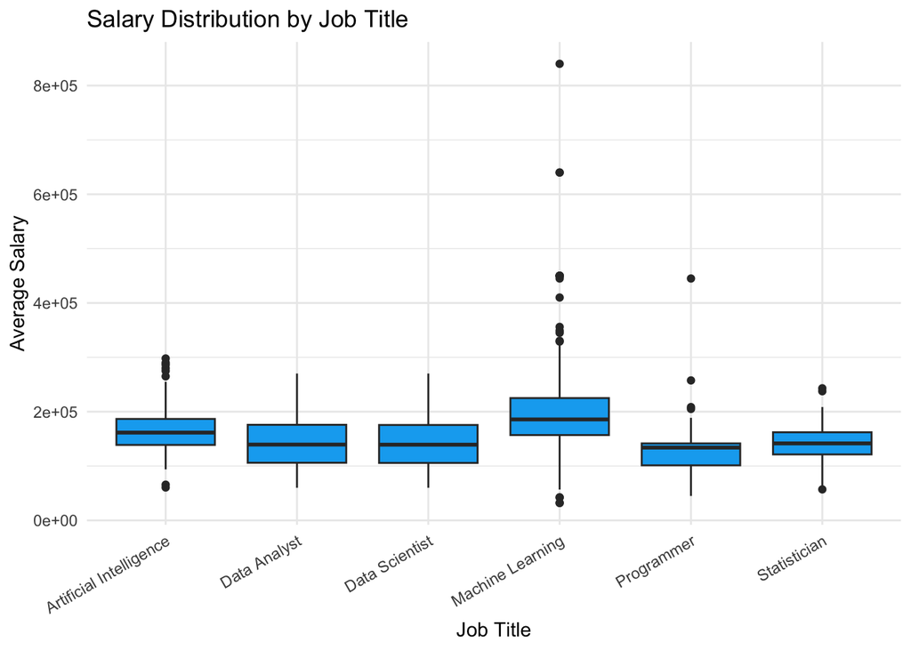

```r
all_jobs <- bind_rows(ds, st, da, pr, ml, ai)

#Since it was optional for the companies to put average salaries, I made sure to only look at the non NA values for the salaries
ggplot(all_jobs %>% filter(!is.na(salary_avg)), aes(x = job, y = salary_avg)) +
  geom_boxplot(fill = "#0eacf1") +
  labs(
    title = "Salary Distribution by Job Title",
    x = "Job Title",
    y = "Average Salary"
  ) +
  theme_minimal() +
  theme(axis.text.x = element_text(angle = 30, hjust = 1))
```

The jobs resulting from Machine Learning as a query has the highest average, as well as the most outliers.

## Task 2

### Selenium

When I started task 2 I thought I would just be able to use the simple Selenium function that Duncan provided to us on GitHub in order to extract all of the HTMLs. After running that code I searched through a few html files at random and noticed that some of them were surprisingly short. After manually investigating those html files (and the links in which those files are contained), I realized that they all had a pop up that said something to the effect of “accept all cookies”. I then researched how I could bypass this pop up to get the actual HTML file underneath. I then reran all of my websites through the altered selenium function (this was before Duncan informed us that we can just run the function on a subset of the urls ☹️). After manually inspecting the same HTMLs that were previously blocked due to the cookie pop up, I saw that the bypass worked, but due to the interest of time I was not able to run new selenium functions to perfectly extract all 1000 HTML files.

```r
html1 <- readRDS("HTML1.RDS")
```

### Task 2 Part 1 (Common Headers)

#### Exploration

- After manually searching through 20-30 websites manually, I felt like I got a generally good idea of what the headers said, so I wanted to make sure that my function could replicate those headers

#### Approach

- I wrote a function that got all of the headers from all of the HTML files (that I have stored as strings) but I quickly realized that there were very similar headers (such as “responsibilities” and “key responsibilities”)
- Because of this, I decided to make another function that took the titles I found using XML and my own keywords as inputs, and spat out a table that combined these common titles together.
- The counts in this frequency seem a little bit low, since from my (limited) manual exploration, most sites had a “responsibilities” (or any similar title), yet this function clocked less than half of these sites having such a header
  - I grew increasingly concerned since at the bottom of the list I got “maximum storage duration”, which was not a header that I encountered when looking at these websites. This suggests that my second passing of extracting the HTMLs using selenium did not scrape the correct HTMLs for every single website, but in the interest of time I decided to continue with the second part of task 2.

```r
titles <- extract_section_titles(html1)
combined_titles <- combine_similar_titles(titles, keywords)
head(sort(table(combined_titles), decreasing = TRUE), 10)
```

```
## combined_titles
##                           skills                         about us
##                              594                              534
## to apply for this job click here                 responsibilities
##                              480                              466
##                   qualifications                  job description
##                              392                              326
##                        education                       experience
##                              219                              208
##                             type         maximum storage duration
##                              206                              205
```

### Task 2 Part 2 (Common Words/Phrases)

#### Approach

- I wanted to look at all of the regular text UNDER the headers that I had previously used in the previous part
- First I get all of the regular text, then I wanted to clean up any stop words, and finally I sorted the frequency of each word in descending order
  - Note that for my stopwords function I removed any words that are 2 or less characters long, just because I can’t think of any integral words of that length

```r
get_common_words(html1)
```

```
## all_words
##             data              job            apply           skills
##             1912             1628              607              604
##      description         engineer            click responsibilities
##              535              525              508              466
##             jobs          similar   qualifications         required
##              452              431              416              410
##           senior             role          analyst             work
##              373              370              354              322
##       experience          summary             type          manager
##              320              316              314              245
##     requirements        analytics          cookies         insenior
##              239              236              236              228
##          storage        education         duration      information
##              223              221              218              212
##       management             lead          maximum        preferred
##              210              207              205              205
##          careers        scientist          company      opportunity
##              196              181              179              173
##             date         benefits         location           travel
##              165              154              148              148
##            india            level            skill              key
##              143              143              142              138
##             sets        associate          posting            title
##              136              134              128              127
##             team          desired
##              123              122
```

#### Analysis

- Most of these words seem appropriate after reading some of the job application sites, but there are some troubling words in the mix
  - cookies: implies that I still did not get past some barrier when opening the site, (need to run another iteration of my function that uses selenium)
  - insenior: I don’t know what this means or how this got up so high on the list

### Getting Common Phrases Among Sites

#### Approach

- I wanted to find phrases between 2 and 5 words that were shared between the websites.
  - I only looked at the text underneath the headers we previously extracted, since I didn’t want to add fluff

#### Challenges

- In my resulting table, there are some phrases that can be nested in larger phrases.
  - Ex: “available work”, “available work visa”, “available work visa sponsorship”
- I wanted to figure out a way such that if a phrase is a subset of another phrase on the list, that phrase would get eliminated from the table. I needed to make sure that the full phrase and the subset phrase had the same frequency (only other option is if the subset has a higher frequency, implying that it was used in a phrase that was not the full “parent” phrase).

```r
get_common_phrases(html1)
```

```
## phrases
##                    similar jobs                   data engineer
##                             426                             255
##                    data analyst                     senior data
##                             184                             174
##                  data scientist             description summary
##                             169                             162
##                      skill sets                        end date
##                             134                             103
##                  data analytics                 required skills
##                              98                              96
##              insenior associate            key responsibilities
##                              93                              90
##                    work summary               skills experience
##                              89                              88
##             travel requirements                visa sponsorship
##                              85                              85
##              clearance required                management level
##                              83                              81
##        preferred qualifications                  available work
##                              81                              80
##             available work visa available work visa sponsorship
##                              80                              80
##               desired languages            government clearance
##                              80                              80
##   government clearance required
##                              80
```

#### Validation

```r
gc <- which(sapply(html1, \(x) grepl("government clearance", extract_visible_text(x), ignore.case = TRUE)))
ds$job_posting_link[head(gc)]
```

```
## [1] "https://citi.wd5.myworkdayjobs.com/en-US/2/job/Heredia--Costa-Rica/Data-Quality-Analytics---Reporting-Lead-Analyst--C13--hybrid-located-in-Costa-Rica_25869580"
## [2] "https://keybank.wd5.myworkdayjobs.com/en-US/external_career_site/job/Remote-United-States/Data-Architect_R-32208"
## [3] "https://clarioclinical.wd1.myworkdayjobs.com/en-US/clarioclinical_careers/job/Costa-Rica-Remote/Clinical-Data-Programmer_R16013-1"
## [4] "https://circlek.wd3.myworkdayjobs.com/en-US/circlekstorejobs/job/Support-Office-India/Lead-Data-Engineer_R507266"
## [5] "https://iaagiz.fa.ocs.oraclecloud.com/hcmUI/CandidateExperience/en/sites/bristlecone-careers/job/16612"
## [6] "https://ebhu.fa.us2.oraclecloud.com/hcmUI/CandidateExperience/en/sites/Careers/job/5631"
```

- Since government clearance was one of the phrases (that seemed off), I wanted to check to see which websites had that in their HTML files, and see if they actually used the phrase
  - Alas, they did not, which means that I most likely had an error when scraping all of these files, but that makes sense considering I only had time to bypass the cookie pop up, without being able to refine my scraping technique.
- That being said, most of the phrases in the table appear to be plausible (although since some of the HTML files are not accurately represented in html1, the frequency of these phrases are most likely lower than in reality).